DS 6030 | Fall 2024 | University of Virginia

# Homework #1: Supervised Learning

Author

**Ben Pelczynski**

Published

September 10, 2024

# Required R packages and Directories

```r
library(tidyverse) # functions for data manipulation
```

# Problem 1: Evaluating a Regression Model

## a. Data generating functions

Create a set of functions to generate data from the following distributions:

$$\begin{align*}
X &\sim \mathcal{N}(0, 1) \\
Y &= -1 + .5X + .2X^2 + \epsilon \\
\epsilon &\sim \mathcal{N}(0,\, \sigma)
\end{align*}$$

**Solution**

```r
generate_X <- function(n){
  X <- rnorm(n, 0, 1)
  return (X)
}

generate_Y <- function(X, e){
  Y <- e + .2*(X**2) + .5*X - 1
  return (Y)
}

generate_e <- function(n, s){
  e <- rnorm(n, 0, s)
  return (e)
}
```

## b. Generate training data

Simulate $n=100$ realizations from these distributions using $\sigma=3$. Produce a scatterplot and draw the true regression line $f(x) = E[Y \mid X=x]$.

- Use `set.seed(611)` prior to generating the data.

**Solution**

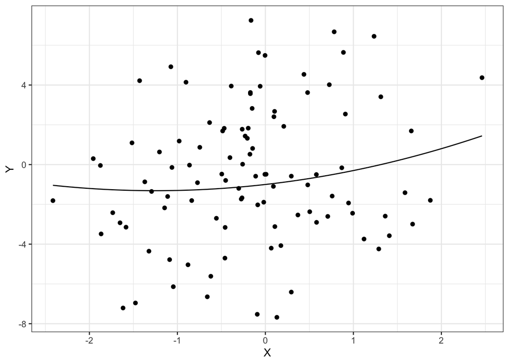

```r
f = function(x){
  .2*(x**2) + .5*x - 1
}

set.seed(611)
X <- generate_X(100)
e <- generate_e(100, 3)
Y <- generate_Y(X, e)
model_data <- data.frame(X,Y,e)
ggplot(model_data, aes(x=X,y=Y))+geom_point()+geom_function(fun=f)
```

## c. Fit three models

Fit three polynomial regression models using least squares: linear, quadratic, and cubic. Produce another scatterplot, add the fitted lines and true population line $f(x)$ using different colors, and add a legend that maps the line color to a model.

- Note: The true model is quadratic, but we are also fitting linear (less complex) and cubic (more complex) models.

**Solution**

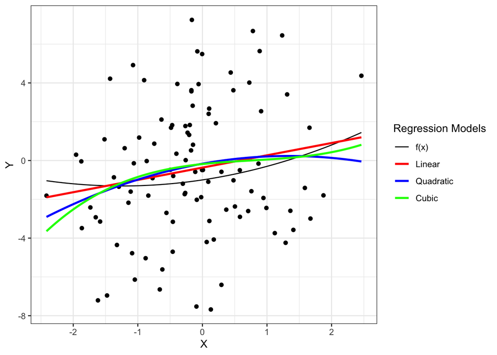

```r
lin_model <- lm(Y~X, data = model_data)
quad_model <- lm(Y~X+I(X**2), data = model_data)
cub_model <- lm(Y~X+I(X**2)+I(X**3), data = model_data)



ggplot(model_data, aes(x=X,y=Y))+geom_point()+geom_function(fun=f, aes(color="f(x)"))+geom_smooth(method='lm', se=FALSE, aes(color='Linear')) + geom_smooth(method='lm', formula = y~x+I(x**2), se=FALSE,  aes(color='Quadratic')) + geom_smooth(method='lm', formula = y~x+I(x**2)+I(x**3), se=FALSE,  aes(color = 'Cubic'))+scale_color_manual(name='Regression Models',breaks=c('f(x)','Linear', 'Quadratic', 'Cubic'),values=c('Cubic'='green', 'Quadratic'='blue', 'Linear'='red', 'f(x)'='black'))
```

## d. Predictive performance

Generate a *test data* set of 10,000 observations from the same distributions. Use `set.seed(612)` prior to generating the test data.

- Calculate the estimated mean squared error (MSE) for each model.
- Are the results as expected?

**Solution**

```r
set.seed(612)
test_X <- generate_X(10000)
test_e <- generate_e(10000, 3)
test_Y <- generate_Y(test_X, test_e)
test_data <- data.frame(X=test_X,Y=test_Y,e=test_e)

lin_predictions <- predict(lin_model, test_data)
lin_mse <- mean((lin_predictions - test_data$Y)^2)
lin_mse
```

```
[1] 9.29
```

```r
quad_predictions <- predict(quad_model, test_data)
quad_mse <- mean((quad_predictions - test_data$Y)^2)
quad_mse
```

```
[1] 9.58
```

```r
cub_predictions <- predict(cub_model, test_data)
cub_mse <- mean((cub_predictions - test_data$Y)^2)
cub_mse
```

```
[1] 9.65
```

The results are not as expected given prior knowledge that the true model is quadratic (meaning the quadratic model should have the least MSE, not the linear model). However, observing the fitted lines of the scatter plot, we can see that the linear model is overall closest to the true f(x), and so the results are as expected for this instance of the training data.

## e. Optimal performance

What is the best achievable MSE? That is, what is the MSE if the true $f(x)$ was used to evaluate the test set? How close does the best method come to achieving the optimum?

**Solution**

```r
true_mse <- mean((f(test_data$X) - test_data$Y)^2)
true_mse
```

```
[1] 8.97
```

The best achievable MSE is 8.97, so while the best method MSE (9.29) is relatively high, it does come fairly close (within one standard deviation) to the optimum.

## f. Replication

The MSE scores obtained in part *d* came from one realization of training data. Here will we explore how much variation there is in the MSE scores by replicating the simulation many times.

- Re-run parts b. and c. (i.e., generate training data and fit models) 100 times.
  - Do not generate new testing data
  - Use `set.seed(613)` prior to running the simulation and do not set the seed in any other places.
- Calculate the test MSE for all simulations.
  - Use the same test data from part d. (This question is only about the variability that comes from the *training data*).
- Create kernel density or histogram plots of the resulting MSE values for each model.

**Solution**

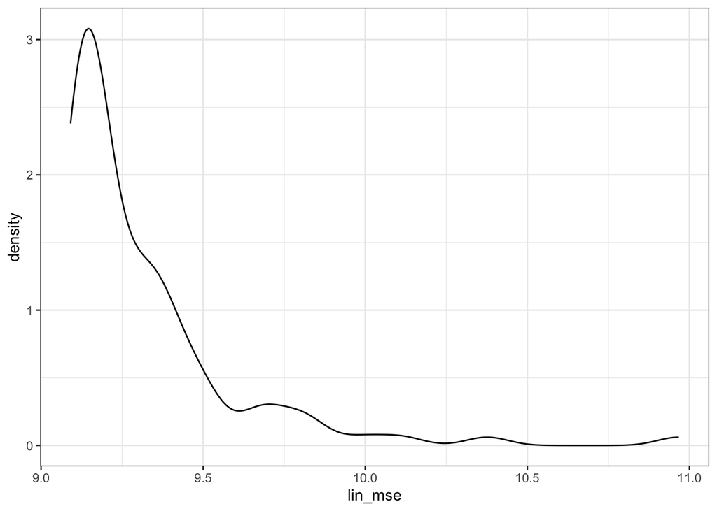

```r
set.seed(613)
replication_MSE <- function(n, test_data){
   mse_data = data.frame(lin_mse=double(), quad_mse=double(),cub_mse=double())
   col_names <- names(mse_data)
   for (x in 1:n) {
     X <- generate_X(100)
     e <- generate_e(100, 3)
     Y <- generate_Y(X, e)
     model_data <- data.frame(X,Y,e)

     lin_model <- lm(Y~X, data = model_data)
     quad_model <- lm(Y~X+I(X**2), data = model_data)
     cub_model <- lm(Y~X+I(X**2)+I(X**3), data = model_data)

     lin_predictions <- predict(lin_model, test_data)
     lin_mse <- mean((lin_predictions - test_data$Y)^2)
     quad_predictions <- predict(quad_model, test_data)
     quad_mse <- mean((quad_predictions - test_data$Y)^2)
     cub_predictions <- predict(cub_model, test_data)
     cub_mse <- mean((cub_predictions - test_data$Y)^2)
     mse_data <- rbind(mse_data, c(lin_mse, quad_mse,cub_mse))
   }
   names(mse_data) <- col_names
   return (mse_data)
}

mse_data <- replication_MSE(100, test_data)
ggplot(mse_data, aes(x=lin_mse))+geom_density()
```

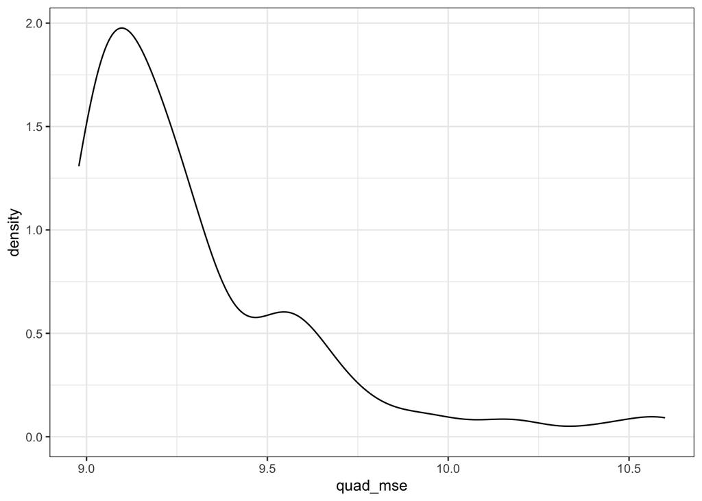

```r
ggplot(mse_data, aes(x=quad_mse))+geom_density()
```

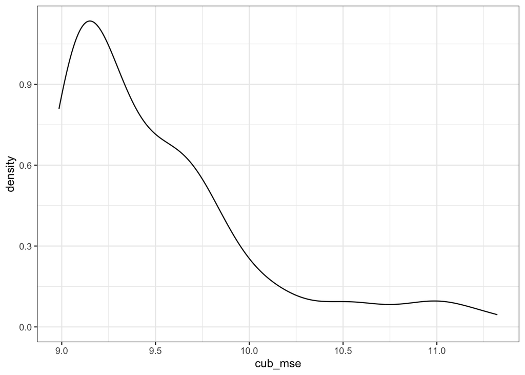

```r
ggplot(mse_data, aes(x=cub_mse))+geom_density()
```

## g. Best model

Show a count of how many times each model was the best. That is, out of the 100 simulations, count how many times each model had the lowest MSE.

**Solution**

```r
lowest_counts <- table(unlist(as.matrix(apply(mse_data,1,which.min))))
names(lowest_counts) <- names(mse_data)
lowest_counts
```

```
 lin_mse quad_mse  cub_mse
      28       65        7
```

## h. Function to implement simulation

Write a function that implements the simulation in part *f*. The function should have arguments for i) the size of the training data $n$, ii) the standard deviation of the random error $\sigma$, and iii) the test data. Use the same `set.seed(613)`.

**Solution**

```r
mse_simulation <- function(n, s, test_data) {
   set.seed(613)
   mse_data = data.frame(lin_mse=double(), quad_mse=double(),cub_mse=double())
   col_names <- names(mse_data)
   for (x in 1:100) {
     X <- generate_X(n)
     e <- generate_e(n, s)
     Y <- generate_Y(X, e)
     model_data <- data.frame(X,Y,e)

     lin_model <- lm(Y~X, data = model_data)
     quad_model <- lm(Y~X+I(X**2), data = model_data)
     cub_model <- lm(Y~X+I(X**2)+I(X**3), data = model_data)

     lin_predictions <- predict(lin_model, test_data)
     lin_mse <- mean((lin_predictions - test_data$Y)^2)
     quad_predictions <- predict(quad_model, test_data)
     quad_mse <- mean((quad_predictions - test_data$Y)^2)
     cub_predictions <- predict(cub_model, test_data)
     cub_mse <- mean((cub_predictions - test_data$Y)^2)
     mse_data <- rbind(mse_data, c(lin_mse, quad_mse,cub_mse))
   }
   names(mse_data) <- col_names
   return (mse_data)
}
```

## i. Performance when $\sigma=2$

Use your function to repeat the simulation in part *f*, but use $\sigma=2$. Report the number of times each model was best (you do not need to produce any plots).

- Be sure to generate new test data with ($n = 10000$, $\sigma = 2$, using `seed = 612`).

**Solution**

```r
set.seed(612)
test_X2 <- generate_X(10000)
test_e2 <- generate_e(10000, 2)
test_Y2 <- generate_Y(test_X2, test_e2)
test_data2 <- data.frame(X=test_X2,Y=test_Y2,e=test_e2)

mse_data2 <- mse_simulation(100, 2, test_data2)
lowest_counts2 <- table(unlist(as.matrix(apply(mse_data2,1,which.min))))
names(lowest_counts2) <- names(mse_data2)
lowest_counts2
```

```
 lin_mse quad_mse  cub_mse
      19       71       10
```

## j. Performance when $\sigma=4$ and $n=300$

Repeat *i*, but now use $\sigma=4$ and $n=300$.

- Be sure to generate new test data with ($n = 10000$, $\sigma = 4$, using `seed = 612`).

**Solution**

```r
set.seed(612)
test_X4 <- generate_X(10000)
test_e4 <- generate_e(10000, 4)
test_Y4 <- generate_Y(test_X4, test_e4)
test_data4 <- data.frame(X=test_X4,Y=test_Y4,e=test_e4)

mse_data4 <- mse_simulation(300, 4, test_data4)
lowest_counts4 <- table(unlist(as.matrix(apply(mse_data4,1,which.min))))
names(lowest_counts4) <- names(mse_data4)
lowest_counts4
```

```
 lin_mse quad_mse  cub_mse
       8       80       12
```

## k. Understanding

Describe the effects $\sigma$ and $n$ has on selection of the best model? Why is the *true* model form (i.e., quadratic) not always the *best* model to use when prediction is the goal?

**Solution**